# Red Replication Report

*N* removed NAs: 3

*N* removed typo: 1

*N* removed <18: 19

*N* total clean: 127

| Group | *N* | *M*<sub>age</sub> | *M*<sub>rating</sub> |
| --- | --- | --- | --- |
| Control | 67 | 20.8 | 6.90 |
| Experim | 60 | 21.4 | 5.92 |

**Main analysis results**

*t*(125) = 7.06, *p* < .001

[interactive chart not shown]

[figure not shown]

[interactive chart not shown]

# Red Replication Report

Analysing Data, Spring 2020

## Method

### Participants

Summary of Participant Age by Condition

| Condition | Count | *M*<sub>age</sub> | *SD*<sub>age</sub> |
| --- | --- | --- | --- |
| Control | 67 | 20.8 | 2.15 |
| Experimental | 60 | 21.4 | 2.22 |

### Design

The hypothesis for this experiment is the colour red shall positively affect perceived attractiveness, with the research question being “Does the colour red affect perceived attractiveness of a male from the perspective of a heterosexual female?” The design consists of the participants viewing an image of an averagely attractive man with either a red or a white frame for 5 seconds. The participants would then rate the man from a scale of 1-9, with 1 being very unattractive and 9 being very attractive, for 3 questions regarding the man’s attractiveness. The categorical independent variable is the colour of the frame, either white (control) or red (experimental). The continuous dependent variable is the attractiveness rating given, with a low score showing the man to be perceived as unattractive and a high score showing the man to be perceived as attractive. From these ratings, a composite score for each condition was created through averaging these scores (using the mean) and the significance of the difference between these scores was measured using a T-test. The operational hypothesis is the image with a red frame shall receive higher attractiveness ratings than the same image with a white frame.

## Results

We investigated whether participants would give higher ratings of attractiveness depending on the colour of the frame the image was presented in, using an independent-measures t-test. This analysis showed, contrary to predictions, that the image with the red frame was in fact rated less attractive than the image with a white frame. The mean attractiveness rating of the experimental condition was (*M* = 5.92) whereas the mean attractiveness rating for the control condition was (*M* = 6.9). This difference in means was significant (*M*<sub>diff</sub> = 0.97, 95% CI [0.7, 1.25], *t* (125) = 7.06, *p* = 0 (.001). These means are visually displayed below

General Pattern of Results using the Composite Score

| Condition | *M*Attractiveness Score | *SD*Attractiveness Score |
| --- | --- | --- |
| Control | 6.90 | 0.65 |
| Experimental | 5.92 | 0.89 |

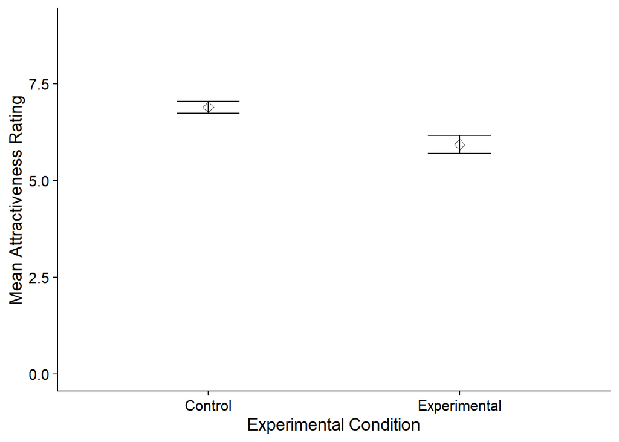

## Discussion

The results of this experiment show that those in the experimental condition, which displayed the image of the man with a red frame surrounding it, rated the man as less attractive than those in the control condition. As these results are statistically significant, we can conclude that the colour red influences perception of attractiveness negatively. This result contradicts both the hypothesis and the null hypothesis.

In the original study (Elliot et al. 2010) which had the same design as the current study, the colour red positively influences the perception of attractiveness. This contradicts the findings in the current study, however both studies convey that red has an effect on attractiveness, just in different ways.

The results from the current study do contradict several other studies, with other “independent laboratories” producing replications which support the original study’s results, as seen in a reply from the creators of the original study (Elliot & Maier, 2013). No other replications found have produced results comparable to the current study’s, with a negative effect of the colour red on attractiveness. That being said, several other replication studies do conclude that there was *no* effect of the colour red on perceived attractiveness (Hesslinger, Goldbach, & Carbon, 2015)(Peperkoorn, Roberts, & Pollet, 2016). In addition, the original study was investigated, where publication bias was tested for and found, raising further speculation regarding the veracity of the original study’s results and claims (Francis 2013). Due to the vastly varying results of several replications of this design, one must scrutinise the results of each test and consider the implications for this area of research on a case by case basis, whether adding to or subtracting from the original hypothesis.

The current study has several strengths and weaknesses. One strength is the operationalisation of the independent variable through the use of scales as this produces an interpretable result of a personal feeling. That being said, the loss of personal emotion in the scoring could be a disadvantage as we lose the meaning behind the scores and ignore how subjective attraction is. The laboratory setting also poses as a strength and a weakness as it allows for high control but sacrifices the ecological validity of the experiment as a laboratory is not typically where one is actively considering attraction. A large weakness of the study is that it lacks generalisability. This study does not take into account the population out of the age range, and those of a different gender, culture or sexuality. These factors are important when considering attraction in general, as without their consideration the results are only applicable to a small portion of the world population.

I believe that the research question is worth investigating further as the current study (in addition to others) reasonably question the results of the studies conducted by Elliot. I believe this would warrant further replications of this study. In addition, I believe investigation into these same effects on homosexual relationships is worth investigating, potentially meaning the same design could be replicated with homosexual women rating an image of a woman and homosexual men rating an image of a man. Another interesting investigation could involve the same research design in different cultures in order to investigate if any effect is present in other cultures as it is in any of these studies. Furthermore, I believe a more ecologically valid rendition of this experiment could be conducted, for example a model either wearing red or white to be rated, to investigate if the lab environment and clinical nature of the experiment affected the participants greatly.

Overall, this study has produced interesting results and this area of research does require further investigation. The speculation regarding this area of research conveys the need for more objective, in-depth experimentation before we can conclude if there is a link between red and attraction, let alone the strength or direction of that link.

## References

1. Elliot, A. J., Kayser, D. N., Greitemeyer, T., Lichtenfeld, S., Gramzow, R. H., Maier, M. A., & Liu, H. (2010). Red, rank, and romance in women viewing men. Journal of Experimental Psychology: General, 139(3), 399–417. doi: 10.1037/a0019689
2. Elliot, A. J., & Maier, M. A. (2013). The red-attractiveness effect, applying the Ioannidis and Trikalinos (2007b) test, and the broader scientific context: A reply to Francis (2013). Journal of Experimental Psychology: General, 142(1), 297–300. doi: 10.1037/a0029592
3. Francis, Gregory. “Publication Bias in ‘Red, Rank, and Romance in Women Viewing Men,’ by Elliot Et Al. (2010).” Journal of Experimental Psychology: General, vol. 142, no. 1, 2013, pp. 292–296., doi:10.1037/a0027923.
4. Hesslinger, V. M., Goldbach, L., & Carbon, C.-C. (2015). Men in red: A reexamination of the red-attractiveness effect. Psychonomic Bulletin & Review, 22(4), 1142–1148. doi: 10.3758/s13423-015-0866-8
5. Peperkoorn, L. S., Roberts, S. C., & Pollet, T. V. (2016). Revisiting the Red Effect on Attractiveness and Sexual Receptivity. Evolutionary Psychology, 14(4), 147470491667384. doi: 10.1177/1474704916673841